← Voltar ao Portal

[figure not shown]

Programa 439

# Síntese Avaliativa do Desempenho dos Programas do PPA Bahia 2024–2027

# **1 - Desempenho Global do Programa**

Este documento apresenta uma Síntese Avaliativa do Desempenho do Programa do Plano Plurianual - PPA 2024- 2027, trazendo uma visão estratégica dos seus resultados, de forma sintética, transparente e colaborativa. Serão levados em consideração o Indicador Sintético de Desempenho do Programa (ISDP), a evolução dos Indicadores de Programa, a eficácia das metas dos Indicadores de Compromisso, o desempenho da execução orçamentária-financeira e da execução física das Ações orçamentárias. O ISDP é uma síntese dessas quatro dimensões, destacando o desempenho do programa em relação aos resultados obtidos e aos esforços despendidos.  
Adicionalmente, são apresentados os principais resultados alcançados, evidenciando os avanços e conformidades dos cinco programas com melhores resultados, além das oportunidades de melhoria dos cinco, com menores resultados. Enquanto neste documento a análise abrange o programa e seus componentes de maneira sintética, nos demais relatórios, a análise detalhada evidencia o comportamento dos componentes do PPA por programas e por órgãos (https://www.ba.gov.br/seplan/monitoramento-e-avaliacao/avaliacao-do-ppa). Além desta Síntese, o [Painel BI - Boletim de Avanços e Oportunidades de Melhoria](https://app.powerbi.com/view?r=eyJrIjoiN2Q0ODliNDItZDFjZi00MGM1LTliNGEtODVmZDAwZTQ1OGEyIiwidCI6IjRjZDgzNWY0LTU0NDAtNDA4Zi05M2EzLTk3NWZjMTdjMzg0YSIsImMiOjR9) oferece informações organizadas em uma perspectiva estratégica do desempenho consolidado dos programas, detalhando, no entanto, cada componente avaliado. A análise nesta seção engloba o programa e seus componentes conforme segue:

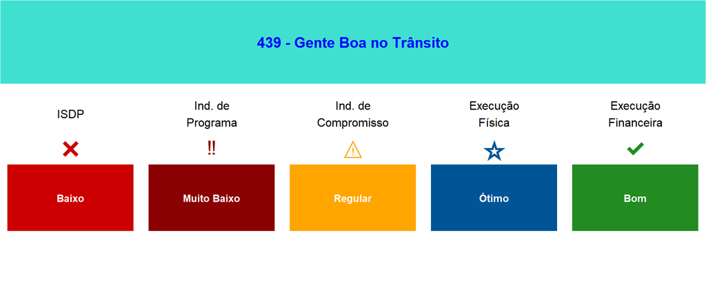

# **2 - Avanços e Conformidades no Programa**

**Indicadores de Programa:** No programa 439 - Gente Boa no Trânsito, também nenhum indicador apresentou evolução positiva.  
**Indicadores de Compromisso:** No programa 439 - Gente Boa no Trânsito, 50% dos indicadores de compromisso apresentaram bom ou ótimo desempenho. Um destaque é o indicador ‘4 - Percentual de Órgãos Municipais de Trânsito (OMT) integrantes do SNT com servidores capacitados’, que atingiu 100,4%. Este resultado foi favorecido por situações normativas que impulsionaram a capacitação online. Outro indicador, ‘3 - Quantidade de novos condutores beneficiados pelo Programa CNH Social’, alcançou 90,11%, porém esse número foi impactado por um atraso no trâmite legal para a regularização do programa, resultando em um início tardio das ações.  
**Ações Orçamentárias:** No Programa 439 - Gente Boa no Trânsito, 58,3% das ações foram consideradas de bom ou ótimo desempenho financeiro, enquanto 91,6% obtiveram essa classificação na execução física. A Ação 2929 - Gestão do Serviço de Licenciamento de Veículo do Estado e a Ação 2943 - Promoção de Campanha Educativa para o Trânsito se destacaram, apresentando resultados ótimos.

# **3 - Oportunidade de Melhoria no Programa**

**Indicadores de Programa:** No Programa 439 - “Gente Boa no Trânsito”, também todos os indicadores apresentaram evolução negativa. O indicador 2227, que mede o percentual de vítimas fatais em sinistros com motociclistas em relação ao total de vítimas fatais de trânsito, aumentou em 17,65%. Este aumento pode ser explicado pelo fato de que 90% dos sinistros que resultam em internação são causados por comportamentos erráticos. Infelizmente, essa tendência de aumento é observada em todo o país.  
**Indicadores de Compromisso:** No programa 439 - Gente Boa no Trânsito, 41,6% dos indicadores de compromisso foram classificados como de desempenho baixo ou muito baixo, e 8,3% tiveram desempenho indeterminado. O indicador ‘5 - Proporção do número de processos julgados e publicados no Diário Oficial Estadual’ teve um desempenho de 21,06%, o que é atribuído a dificuldades institucionais, especialmente pela falta da criação de novas Juntas Administrativas de Recursos e Infrações. O indicador ‘8 - Proporção de empresas credenciadas pelo DETRAN fiscalizadas’ apresentou apenas 16,4%, resultado que pode ser justificado pelo término de contratos de servidores que compunham as equipes de fiscalização, sem reposição efetiva de pessoal.  
**Ações Orçamentárias:** No entanto, no Programa 439 - Gente Boa no Trânsito, 25% das ações apresentaram desempenho baixo ou muito baixo na execução financeira, e 8,3% na execução física. A ação 4195 - Fiscalização de Empresas Credenciadas pelo Departamento Estadual de Trânsito (Detran) obteve classificações “Baixo” e “Muito Baixo”.

Desenvolvido por: DAP – Diretoria de Avaliação de Políticas Públicas